# Sustainable Spatial Planning and Analysis

Urban Bikeability Equity in Lima, Peru

Author

weemuk

# Overview

Active travel infrastructure in the Lima Metropolitan Area is characterized by a severe socio-spatial divide. While central districts benefit from connected cycle networks and flat terrain, peripheral areas endure a lack of infrastructure, steep topography, and high traffic stress (Guzman, Oviedo, and Rivera 2017). This report develops a Bikeability Index to quantify this inequity and evaluate proposed municipal cycling projects.

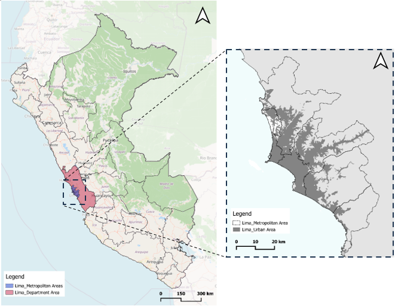

Figure 1: Study Area - Metropolitan Area of Lima

# Methodology

The study employs a grid-based Spatial Multi-Criteria Analysis (SMCA) mapped over 100 x 100 m cells within Lima’s inhabited urban boundary. The index integrates five spatial variables, calculating localized values within a 250 m catchment buffer representing the average acceptable cycling detour (Krenn, Oja, and Titze 2015).

To create a unified Bikeability Index, the raw data for these five variables was categorized into a discrete 1 to 10 scale (where 10 indicates high bikeability) based on statistical deciles (Winters et al. 2013; Santos et al. 2022).

Abridged Variable Classification Framework:

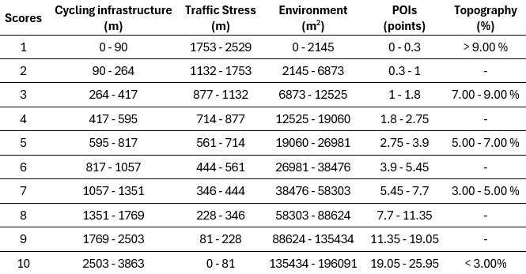

Figure 2: Classification of the 5 variables in deciles (1: low bikeability, 10: high bikeability)

# Key Findings: The Socio-Spatial Gap

The resulting index reveals that optimal cycling conditions, defined as scores between 6 and 8, are heavily concentrated in the flat, well-connected ‘Centric Lima’ area. Conversely, urban peripheries present highly unfavorable environments for active travel modes due to moderate slopes and arterial road traffic.

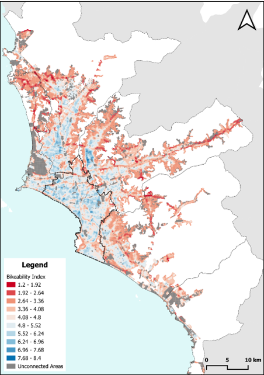

Figure 3: Bikeability Index of the Metropolitan Area of Lima

By integrating 2021 population data, the severity of this inequity becomes quantifiable.

- Approximately 63% of Lima’s residents live in areas with a Bikeability Index score below 4, facing compounding spatial barriers and a lack of connected infrastructure.
- Only a minority of the population (around 12%) resides in areas considered accessible for cycling (scores of 6 to 8).

# Policy Implications & Limitations

An analysis of the Metropolitan Municipality of Lima’s future cycle infrastructure projects indicates a continued focus on improving connectivity within the already dense central districts. This approach will inadvertently continue to marginalise peripheral areas that possess high destination density (POIs) but lack dedicated infrastructure. The report recommends shifting from a coverage-based metric to an accessibility-based metric that prioritises these underserved peripheral zones.

# Conclusions

Finally, the report acknowledges methodological limitations (Arellana et al. 2020; Cervero et al. 2009; Lu, Sarkar, and Xiao 2018), most notably the exclusion of a personal safety variable. In the Latin American context, the perceived risk of street crime is a critical determinant in active travel behavior, which may negatively offset the benefits of segregated cycle lanes. Additionally, utilizing park area as an environmental proxy fails to account for the quality of shading and thermal comfort provided by trees.

## References

Arellana, Julián, María Saltarín, Ana Margarita Larrañaga, Virginia I. González, and César Augusto Henao. 2020. “Developing an Urban Bikeability Index for Different Types of Cyclists as a Tool to Prioritise Bicycle Infrastructure Investments.” *Transportation Research Part A: Policy and Practice* 139 (September): 310–34. https://doi.org/10.1016/j.tra.2020.07.010.

Cervero, Robert, Olga L. Sarmiento, Enrique Jacoby, Luis Fernando Gomez, and Andrea Neiman. 2009. “Influences of Built Environments on Walking and Cycling: Lessons from Bogotá.” *International Journal of Sustainable Transportation* 3 (4): 203–26. https://doi.org/10.1080/15568310802178314.

Guzman, Luis A., Daniel Oviedo, and Carlos Rivera. 2017. “Assessing Equity in Transport Accessibility to Work and Study: The Bogotá Region.” *Journal of Transport Geography* 58 (January): 236–46. https://doi.org/10.1016/j.jtrangeo.2016.12.016.

Krenn, Patricia Jasmin, Pekka Oja, and Sylvia Titze. 2015. “Development of a Bikeability Index to Assess the Bicycle-Friendliness of Urban Environments.” *Open Journal of Civil Engineering* 05 (04): 451–59. https://doi.org/10.4236/ojce.2015.54045.

Lu, Yi, Chinmoy Sarkar, and Yang Xiao. 2018. “The Effect of Street-Level Greenery on Walking Behavior: Evidence from Hong Kong.” *Social Science & Medicine* 208 (July): 41–49. https://doi.org/10.1016/j.socscimed.2018.05.022.

Santos, Bertha, Sílvia Passos, Jorge Gonçalves, and Isabel Matias. 2022. “Spatial Multi-Criteria Analysis for Road Segment Cycling Suitability Assessment.” *Sustainability* 14 (16): 9928. https://doi.org/10.3390/su14169928.

Winters, Meghan, Michael Brauer, Eleanor M Setton, and Kay Teschke. 2013. “Mapping Bikeability: A Spatial Tool to Support Sustainable Travel.” *Environment and Planning B: Planning and Design* 40 (5): 865–83. https://doi.org/10.1068/b38185.